# Homework 5

Lauren Smith

October 17, 2019

# Exercise 1: Explain the value of the here::here package

## 1.1 In your own words, summarize the value of the here::here package in 250 words or fewer.

From my understanding, the here::here package is valuable because it allows you to more easily specify where you want a file to be created. It makes the data more accessible to other people (and across operating systems) as well.

# Exercise 2: Factor management

## 2.1. Choose one dataset and a variable to explore.

The data set that I will explore is ‘gapminder’ and the variable is ‘country’.

```r
data(gapminder)
gapminder
```

```
## # A tibble: 1,704 x 6
##    country     continent  year lifeExp      pop gdpPercap
##    <fct>       <fct>     <int>   <dbl>    <int>     <dbl>
##  1 Afghanistan Asia       1952    28.8  8425333      779.
##  2 Afghanistan Asia       1957    30.3  9240934      821.
##  3 Afghanistan Asia       1962    32.0 10267083      853.
##  4 Afghanistan Asia       1967    34.0 11537966      836.
##  5 Afghanistan Asia       1972    36.1 13079460      740.
##  6 Afghanistan Asia       1977    38.4 14880372      786.
##  7 Afghanistan Asia       1982    39.9 12881816      978.
##  8 Afghanistan Asia       1987    40.8 13867957      852.
##  9 Afghanistan Asia       1992    41.7 16317921      649.
## 10 Afghanistan Asia       1997    41.8 22227415      635.
## # ... with 1,694 more rows
```

```r
CO2$Treatment %>%
  str()
```

```
##  Factor w/ 2 levels "nonchilled","chilled": 1 1 1 1 1 1 1 1 1 1 ...
```

## 2.2. After ensuring the variable(S) you’re exploring are indeed factors, you should:

### 2.2.1. Drop factor/levels;_

```r
new_gap <- gapminder %>%
  filter(country %in% c("Norway", "Germany", "Chile", "Canada", "Uganda", "Italy"))

new_gap$country %>%
  nlevels()
```

```
## [1] 142
```

```r
new_gap_dropped <- new_gap %>%
  droplevels()
new_gap_dropped
```

```
## # A tibble: 72 x 6
##    country continent  year lifeExp      pop gdpPercap
##    <fct>   <fct>     <int>   <dbl>    <int>     <dbl>
##  1 Canada  Americas   1952    68.8 14785584    11367.
##  2 Canada  Americas   1957    70.0 17010154    12490.
##  3 Canada  Americas   1962    71.3 18985849    13462.
##  4 Canada  Americas   1967    72.1 20819767    16077.
##  5 Canada  Americas   1972    72.9 22284500    18971.
##  6 Canada  Americas   1977    74.2 23796400    22091.
##  7 Canada  Americas   1982    75.8 25201900    22899.
##  8 Canada  Americas   1987    76.9 26549700    26627.
##  9 Canada  Americas   1992    78.0 28523502    26343.
## 10 Canada  Americas   1997    78.6 30305843    28955.
## # ... with 62 more rows
```

## 2.3. Explore the effects of re-leveling a factor in a tibble by:

### 2.3.1. Comparing the results of `arrange` on the original and re-leveled factor.

Now that the data have been filtered and unused levels dropped, we can create bar plots to see how many entries are present in each continent of interest. Let’s see what using ‘arrange’ looks like first.

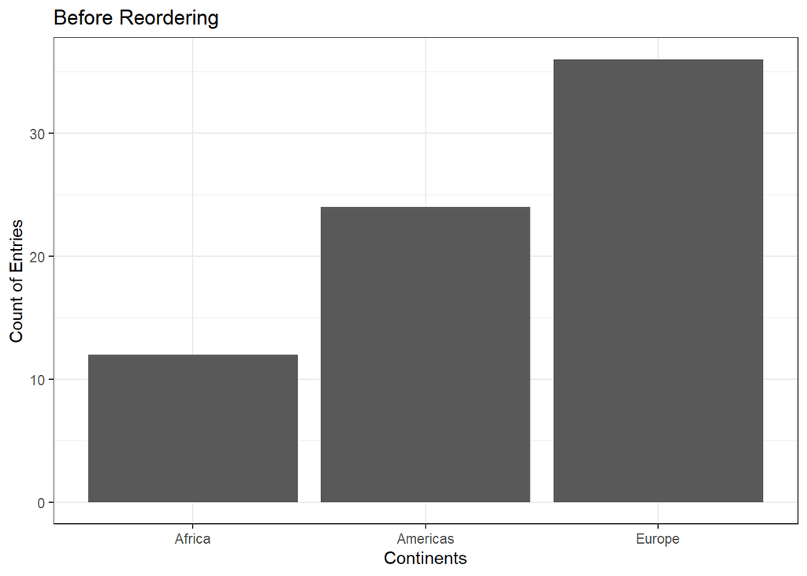

```r
new_gap_dropped %>%
  arrange(continent) %>%
  ggplot(aes(continent)) +
  geom_bar() +
  theme_bw() +
  labs(title = "Before Reordering", x = "Continents", y = "Count of Entries")
```

### 2.3.2. Plotting a figure of before/after re-leveling the factor (make sure to assign the factor to an aesthetic of your choosing).

Now let’s use the fct_reorder function to put the bars in order of maximum life expectancy.

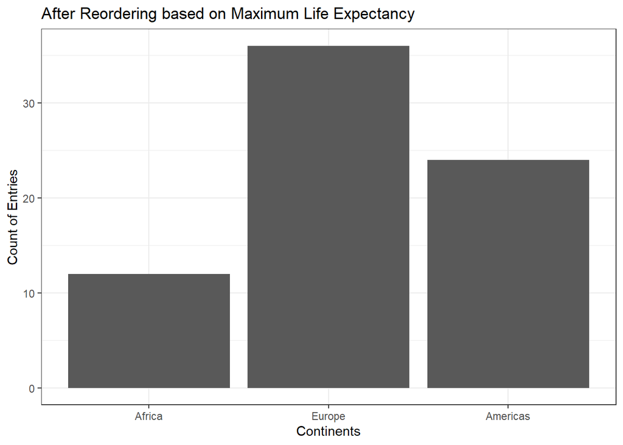

```r
new_gap_dropped %>%
  ggplot() +
  geom_bar(aes(fct_reorder(continent, lifeExp, max))) +
  theme_bw() +
  labs(title = "After Reordering based on Maximum Life Expectancy", x = "Continents", y = "Count of Entries")
```

# Exercise 3: File input/output (I/O)

## 3.1. Experiment with at least one of:

### - `write_csv()/read_csv()`

Here I am going to read in a very trimmed down .csv file of some data from my undergraduate research on spiders in grasslands. I’m not sure how to prevent R from reading in the blank columns and blank rows… There should be 8 columns and 133 rows of data. Any helpful information here would be great.

```r
spiders <- read_csv(here::here("spiderdata", "spiders_stats545.csv"))
spiders
```

```
## # A tibble: 498 x 40
##    Site  Plot  Type  Date  Order Family Sex   Age   X9    X10   X11   X12
##    <chr> <chr> <chr> <chr> <chr> <chr>  <chr> <chr> <lgl> <lgl> <lgl> <lgl>
##  1 TNC-B R1    Rest~ 6/16~ Aran~ Thomi~ Fema~ Adult NA    NA    NA    NA
##  2 TNC-B R1    Rest~ 6/16~ Aran~ Thomi~ Unkn~ Imma~ NA    NA    NA    NA
##  3 TNC-B R1    Rest~ 6/16~ Aran~ Thomi~ Unkn~ Imma~ NA    NA    NA    NA
##  4 TNC-B R1    Rest~ 6/16~ Aran~ Thomi~ Unkn~ Imma~ NA    NA    NA    NA
##  5 TNC-B R1    Rest~ 6/16~ Aran~ Thomi~ Unkn~ Imma~ NA    NA    NA    NA
##  6 TNC-B R1    Rest~ 6/16~ Aran~ Thomi~ Unkn~ Unkn~ NA    NA    NA    NA
##  7 TNC-B R2    Rest~ 6/16~ Aran~ Thomi~ Fema~ Adult NA    NA    NA    NA
##  8 TNC-B R2    Rest~ 6/16~ Aran~ Thomi~ Unkn~ Imma~ NA    NA    NA    NA
##  9 TNC-B R2    Rest~ 6/16~ Aran~ Thomi~ Unkn~ Imma~ NA    NA    NA    NA
## 10 TNC-B R2    Rest~ 6/16~ Aran~ Thomi~ Unkn~ Imma~ NA    NA    NA    NA
## # ... with 488 more rows, and 28 more variables: X13 <lgl>, X14 <lgl>,
## #   X15 <lgl>, X16 <lgl>, X17 <lgl>, X18 <lgl>, X19 <lgl>, X20 <lgl>,
## #   X21 <lgl>, X22 <lgl>, X23 <lgl>, X24 <lgl>, X25 <lgl>, X26 <lgl>,
## #   X27 <lgl>, X28 <lgl>, X29 <lgl>, X30 <lgl>, X31 <lgl>, X32 <lgl>,
## #   X33 <lgl>, X34 <lgl>, X35 <lgl>, X36 <lgl>, X37 <lgl>, X38 <lgl>,
## #   X39 <lgl>, X40 <lgl>
```

# Exercise 4: Visualization design

## 4.1. Recreate at least one figure in light of something you learned in the recent class meetings about visualization design and color.

## 4.2. Create a side-by-side plot and juxtapose your first attempt (show the original figure as-is) with a revised attempt after some time spent working on it and implementing principles of effective plotting principles. Comment and reflect on the differences.

For these two exercises, I am using a figure that I created during Homework 2 using the ‘Orange’ dataset.

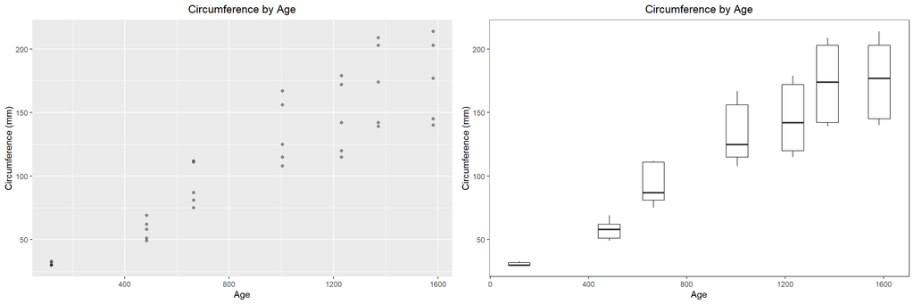

```r
data(Orange)

#old graph
graph1 <- Orange %>%
  ggplot(aes(age, circumference)) +
  geom_point(alpha = 0.4) +
  labs(title = "Circumference by Age", x = "Age", y = "Circumference (mm)") +
  theme(plot.title = element_text(hjust = 0.5))

#new graph
graph2 <- Orange %>%
  ggplot(aes(age, circumference, group = age)) +
  geom_boxplot() +
  labs(title = "Circumference by Age", x = "Age", y = "Circumference (mm)") +
  theme_bw() +
  theme(panel.grid.major = element_blank(), panel.grid.minor = element_blank(), plot.title = element_text(hjust = 0.5))

grid.arrange(graph1, graph2, nrow = 1)
```

To recreate this file using the new material that we have learned, I am going to use certain features of ggplot to create a more effective graph - including removing the grid lines and grey background of the plot. I switched to using a boxplot because I think it represents that differences in circumference at different ages better. It shows the variation in data rather than just the single data points.

# Exercise 5: Writing figures to file

## 5.1. Task: Use `ggsave()` to explicitly save a plot to file. Include the exported plot as part of your repository and assignment.

I am going to use the new graph that I created in Exercise 4 for this exercise.

First, I’ll save the graph using the defaults of ‘ggsave()’. This saves a 7 by 7 inch .png file.

```r
ggsave("orange_boxplot.png")
```

### Then, use `![Alt text](/path/to/img.png)` to load and embed that file into your report. You can play around with various options, such as:

### - Arguments of `ggsave()`, such as width, height, resolution or text scaling.

Change the dimensions and resolution:

```r
ggsave("resized_orange_boxplot.png", width = 5, height = 4, dpi = 150)
```

### - Various graphics devices, e.g. a vector vs. raster format.

Change the output format:

```r
ggsave("jpeg_orange_boxplot.jpeg")
```

### - Explicit provision of the plot object `p` via `ggsave(..., plot = p)`. Show a situation in which this actually matters.

How to specify which graph to save. ggsave() defaults to saving the last plot.

```r
ggsave("old_orange_graph.png", plot = graph1)
```

Embedded graph:

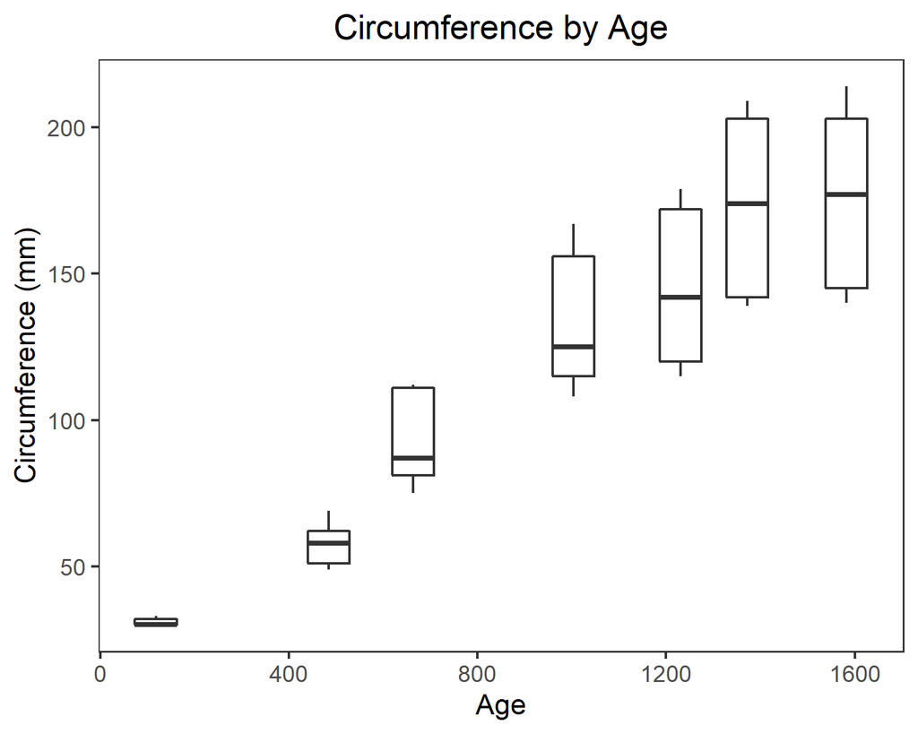

```r
ggsave("new_orange_plot.png", width = 5, height = 4, units = "in", plot = graph2)
```